# XL’s_presentation

10/8/2021

## Overview

- Datasets chosen: From https://www.gapminder.org/data/
- Two indicators in two datasets: Babies per women(total fertility) - & Employment rate(%), females aged 15+
- Country chosen: Top Five Fastest Developing Countries from https://borgenproject.org/top-5-fastest-developing-countries/
  - which are Argentina, India , China, Brazil, Guyana - Five Developed Countries
  - which are United States, France, United Kingdom, Belgium, Spain

## Developed Countries: Fertility

- (United States, France, United Kingdom, Belgium, Spain)

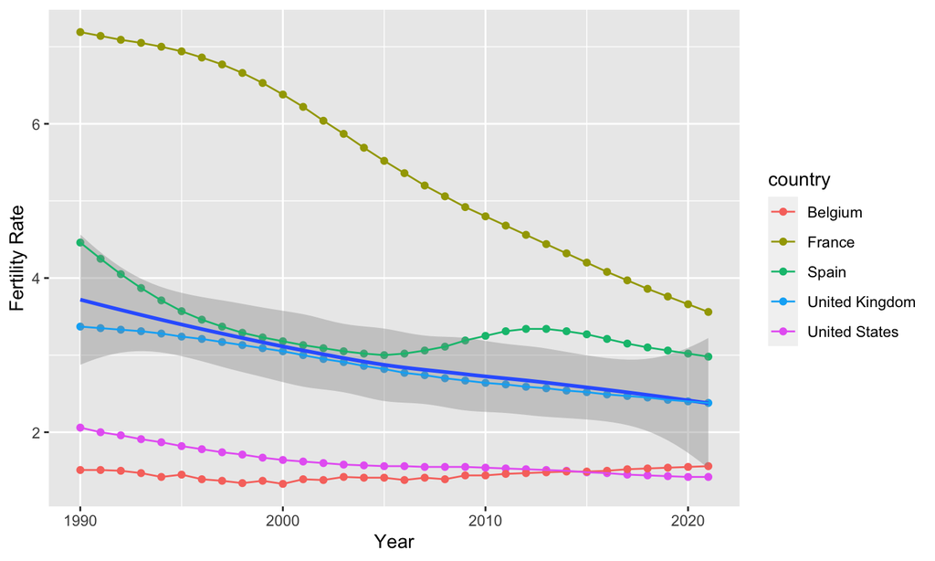

## Developed Countries: Employment%

- (United States, France, United Kingdom, Belgium, Spain)

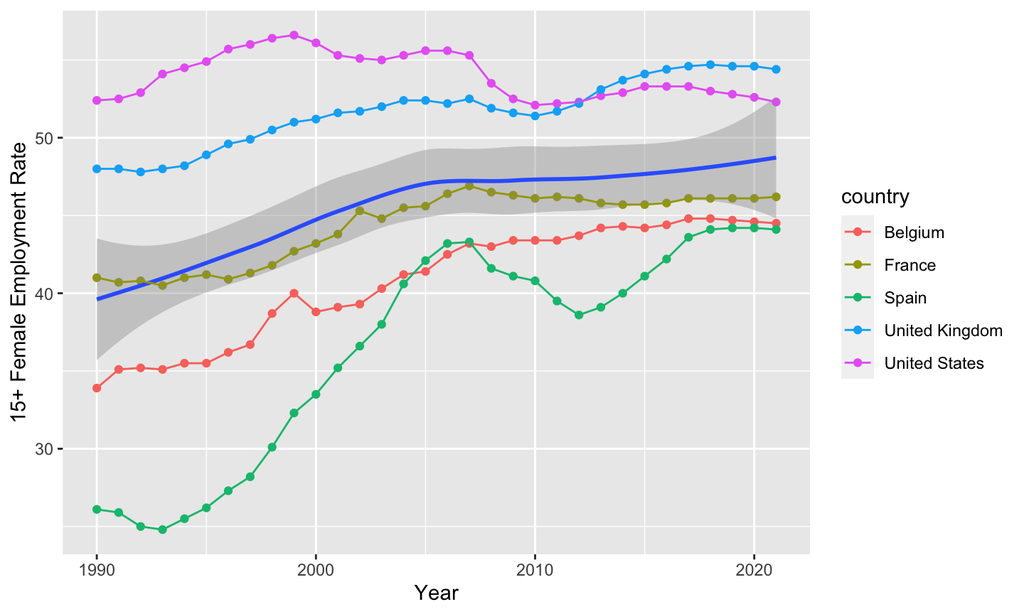

## Developing Countries: Fertility

- (Argentina, India , china, Brazil, guyana)

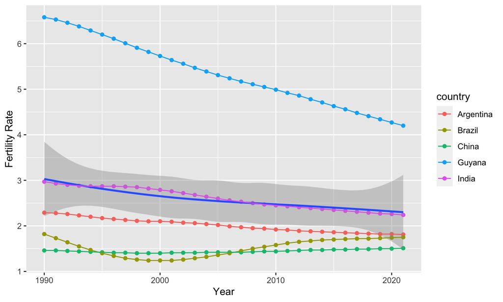

## Developing Countries: Employment%

- (Argentina, India , china, Brazil, guyana)

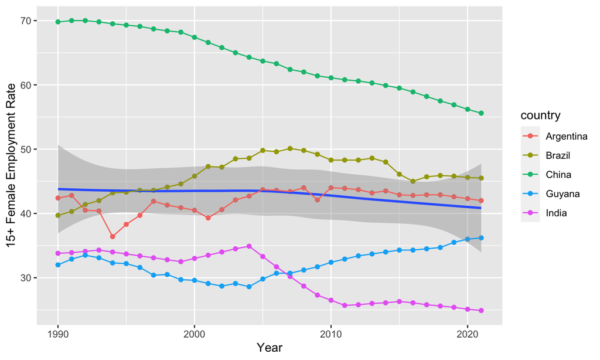

## Thought

- Before I analyzed these two data sets, I think that the employment rate should be increasing no matter in which kinds country, especially, I chose five top fast developing countries in the world.
- Moreover, I used to believe that the fertility rate is decreasing and one of the main reason is that female’s employment rate is increasing.
- The employment rates have different trend in developed and developing countries.